# Proyecto Final AEM

Rubén Gil Martínez

2024-04-09

```r
d <- read.csv("data/Mercado_valores_USA.csv")
```

PRIMERAMENTE REALIZAREMOS UN PREPROCESADO DEL CONJUNTO DE DATOS PARA QUEDARNOS SOLAMENTE CON VARIABLES NUMÉRICAS QUE NOS PERMITAN CONSTRUIR EL MODELO DE REGRESIÓN LINEAL MÚLTIPLE ÓPTIMO PARA PREDECIR EL VALOR DE BITCOIN, COMO HEMOS COMENTADO, LA VARIABLE Bitcoin_Price SERÁ LA VARIABLE RESPUESTA.

PRIMERAMENTE REALIZAMOS UN PREPROCESADO:

ELIMINAMOS DEL CONJUNTO DE DATOS TODAS LAS VARIABLES QUE NO NOS INTERESAN QUE SON: LOS VOLÚMENES DE MERCADO DE LOS DISTINTOS ACTIVOS, TAMBIÉN VAMOS PRESCINDIR DE LAS COLUMNAS QUE NOS INDICAN EL ÍNDICE Y LAS DISTINTAS FECHAS

```r
library(dplyr)
d <- d %>%
  select(ends_with("_Price"))
```

UNA VEZ TENEMOS LOS DISTINTOS PRECIOS DE LOS 19 ACTIVOS QUE VAMOS A EMPLEAR PARA CONSTRUIR EL MODELO, VAMOS A REALIZAR UN ESTUDIO ESTADÍSTICO PREVIO:

```r
# ESTRUCTURA DE LOS DATOS:
str(d)
```

```
## 'data.frame':    1243 obs. of  19 variables:
##  $ Natural_Gas_Price: num  2.08 2.05 2.1 2.08 2.49 ...
##  $ Crude_oil_Price  : num  72.3 73.8 75.8 77.8 76.8 ...
##  $ Copper_Price     : num  3.82 3.85 3.91 3.91 3.88 ...
##  $ Bitcoin_Price    : num  43195 43081 42581 42946 43300 ...
##  $ Platinum_Price   : num  902 922 933 932 938 ...
##  $ Ethereum_Price   : num  2309 2304 2283 2343 2318 ...
##  $ S.P_500_Price    : num  4959 4906 4849 4925 4928 ...
##  $ Nasdaq_100_Price : num  17643 17345 17137 17477 17596 ...
##  $ Apple_Price      : num  186 187 184 188 192 ...
##  $ Tesla_Price      : num  188 189 187 192 191 ...
##  $ Microsoft_Price  : num  411 404 398 409 410 ...
##  $ Silver_Price     : num  22.8 23.2 23.2 23.2 23.1 ...
##  $ Google_Price     : num  142 141 140 151 154 ...
##  $ Nvidia_Price     : num  662 630 615 628 625 ...
##  $ Berkshire_Price  : int  589498 581600 578020 584680 578800 582300 576211 570977 564133 558316 ...
##  $ Netflix_Price    : num  565 568 564 563 576 ...
##  $ Amazon_Price     : num  172 159 155 159 161 ...
##  $ Meta_Price       : num  475 395 390 400 401 ...
##  $ Gold_Price       : num  2054 2071 2067 2051 2035 ...
```

```r
# RESUMEN ESTADÍSTICO DE LOS DATOS
summary(d)
```

```
##  Natural_Gas_Price Crude_oil_Price   Copper_Price   Bitcoin_Price
##  Min.   :1.482     Min.   :-37.63   Min.   :2.100   Min.   : 3398
##  1st Qu.:2.348     1st Qu.: 55.09   1st Qu.:2.859   1st Qu.:10015
##  Median :2.702     Median : 69.23   Median :3.666   Median :23055
##  Mean   :3.495     Mean   : 67.58   Mean   :3.542   Mean   :25242
##  3rd Qu.:4.056     3rd Qu.: 80.45   3rd Qu.:4.137   3rd Qu.:37784
##  Max.   :9.647     Max.   :123.70   Max.   :4.938   Max.   :67528
##  Platinum_Price   Ethereum_Price   S.P_500_Price  Nasdaq_100_Price
##  Min.   : 595.2   Min.   : 104.5   Min.   :2237   Min.   : 6905
##  1st Qu.: 889.8   1st Qu.: 244.1   1st Qu.:3191   1st Qu.: 9299
##  Median : 944.7   Median :1552.6   Median :3933   Median :12381
##  Mean   : 959.0   Mean   :1445.8   Mean   :3793   Mean   :12037
##  3rd Qu.:1020.4   3rd Qu.:2056.6   3rd Qu.:4349   3rd Qu.:14563
##  Max.   :1297.1   Max.   :4808.4   Max.   :4959   Max.   :17643
##   Apple_Price      Tesla_Price     Microsoft_Price  Silver_Price
##  Min.   : 42.36   Min.   : 11.93   Min.   :105.2   Min.   :11.77
##  1st Qu.: 79.50   1st Qu.: 53.34   1st Qu.:182.5   1st Qu.:18.00
##  Median :136.76   Median :202.07   Median :245.4   Median :22.76
##  Mean   :125.57   Mean   :173.59   Mean   :241.2   Mean   :21.59
##  3rd Qu.:162.91   3rd Qu.:251.47   3rd Qu.:297.1   3rd Qu.:24.51
##  Max.   :198.11   Max.   :409.97   Max.   :411.2   Max.   :29.42
##   Google_Price     Nvidia_Price    Berkshire_Price  Netflix_Price
##  Min.   : 51.94   Min.   : 33.45   Min.   :240000   Min.   :166.4
##  1st Qu.: 71.19   1st Qu.: 73.91   1st Qu.:318985   1st Qu.:323.0
##  Median :101.24   Median :151.59   Median :418349   Median :384.1
##  Mean   : 99.67   Mean   :187.29   Mean   :404273   Mean   :404.8
##  3rd Qu.:127.20   3rd Qu.:242.14   3rd Qu.:471500   3rd Qu.:495.4
##  Max.   :153.51   Max.   :661.60   Max.   :589498   Max.   :691.7
##   Amazon_Price      Meta_Price       Gold_Price
##  Min.   : 79.41   Min.   : 88.91   Min.   :1272
##  1st Qu.: 96.26   1st Qu.:183.35   1st Qu.:1670
##  Median :128.73   Median :224.43   Median :1804
##  Mean   :128.68   Mean   :239.73   Mean   :1759
##  3rd Qu.:158.11   3rd Qu.:301.65   3rd Qu.:1913
##  Max.   :186.57   Max.   :474.99   Max.   :2090
```

```r
# PODEMOS OBSERVAR QUE VAMOS A TENER QUE NORMALIZAR LOS DATOS PARA QUE VARIABLES COMO EL PRECIO DE BERKSHIRE NO INFLUYAN DE MÁS EN MODELO DEBIDO A SU ESCALA, QUE ES DESPROPORCIONADAMENTE MAYOR A LA DE LA MAYORÍA DE VARIABLES.
```

```r
# MEDIA Y D.TÍPICA DE LA VARIABLE RESPUESTA, GUARDAMOS ESTOS VALORES PARA DESPUÉS PODER HACER PREDICCIONES CON LOS VALORES REALES DEL ACTIVO YA QUE LO TIPIFICAMOS A LA HORA DE CONSTRUIR Y ENTRENAR EL MODELO :
media_bitcoin <- mean(d$Bitcoin_Price)
dtipica_bitcoin <- sd(d$Bitcoin_Price)
media_bitcoin
```

```
## [1] 25241.9
```

```r
dtipica_bitcoin
```

```
## [1] 16029.01
```

VEAMOS SI PODRÍAMOS APLICAR ANÁLISIS DE COMPONENTES PRINCIPALES:

VAMOS A ANALIZAR EL GRÁFICO DE NUBE DE PUNTOS Y LA MATRIZ DE CORRELACIONES PARA OBSERVAR SI HAY VARIABLES CORRELADAS.

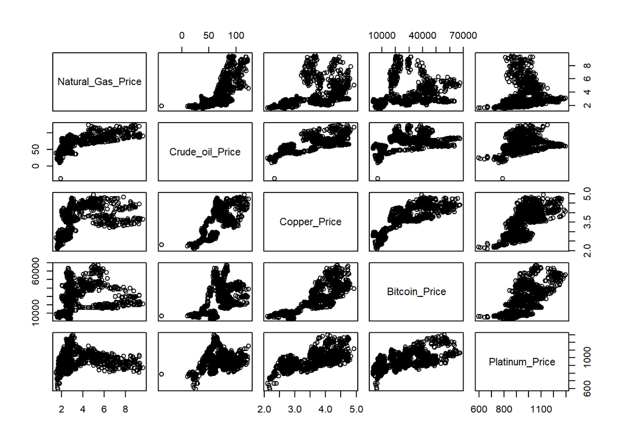

```r
# AL HABER TANTA CANTIDAD DE VARIABLES ES DIFÍCIL REALIZAR LA NUBE DE PUNTOS PARA TODAS LAS VARIABLES, TOMAREMOS ALGUNAS VARIABLES Y LAS REPRESENTAREMOS PARA VISUALIZAR LA FORMA DE LAS NUBES:

plot(d[,c(1:5)])
```

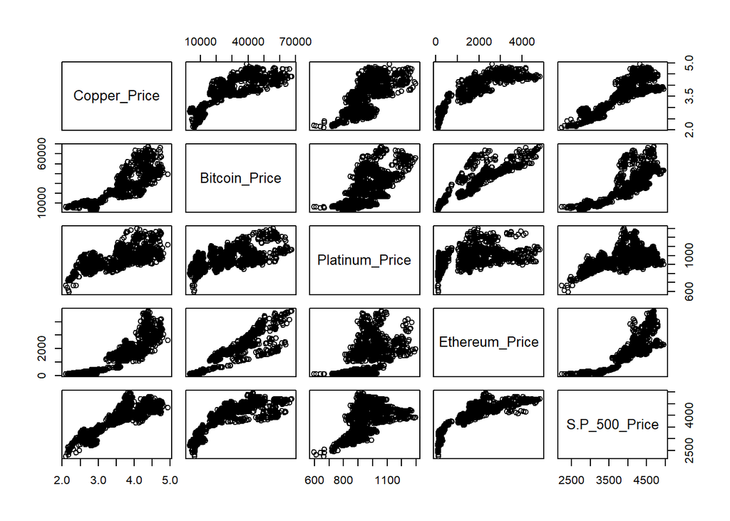

```r
plot(d[,c(3:7)])
```

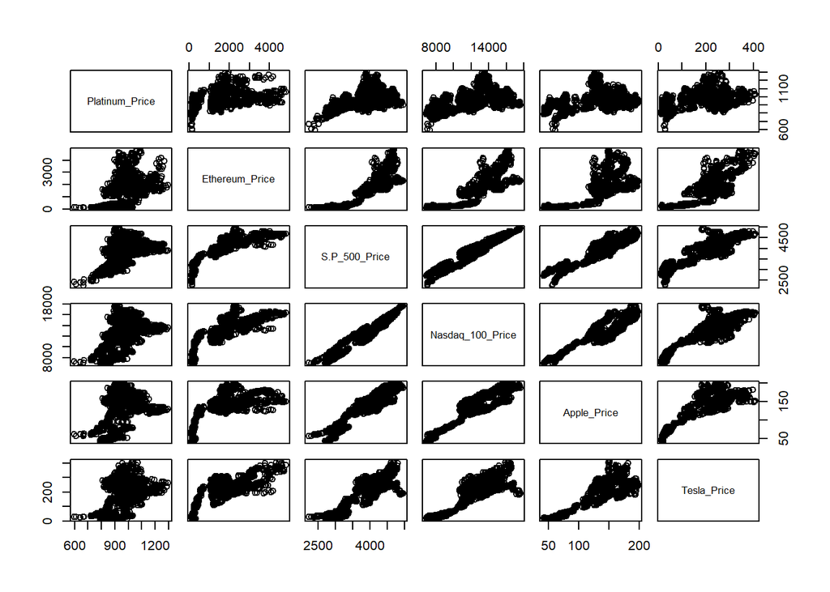

```r
plot(d[,c(5:10)])
```

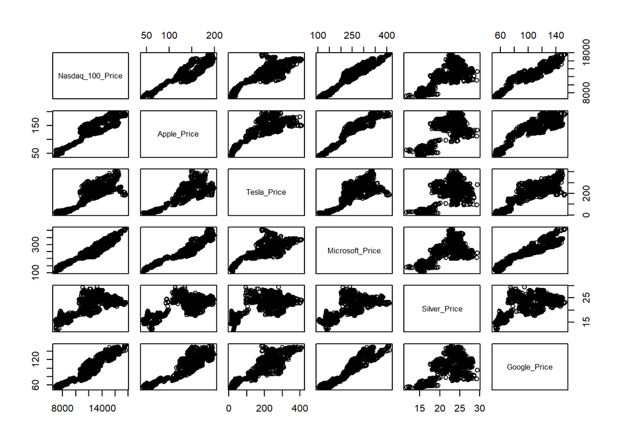

```r
plot(d[,c(8:13)])
```

```r
# PODEMOS OBSERVAR QUE TENEMOS BASTANTES VARIABLES CORRELADAS ENTRE SÍ.
```

```r
correlaciones <- cor(d) # Matriz de correlaciones


print("Porcentaje de pares de variables considerablemente correladas respecto del total sin contar los pares de misma variable: ")
```

```
## [1] "Porcentaje de pares de variables considerablemente correladas respecto del total sin contar los pares de misma variable: "
```

```r
sum(correlaciones > 0.5 & correlaciones < 1) / sum(correlaciones < 1) * 100
```

```
## [1] 69.00585
```

```r
# Casi el 70% de las variables presentan una correlación mayor de 0.5.
```

```r
#library(Hmisc)
#rcorr(as.matrix(d))

 # CALCULA LA MATRIZ DE CORRELACIONES Y QUE TAN SIGNIFICATIVAS SON ESTAS PARA SABER SI ES DE UTILIDAD REALIZAR ACP.
# INCISO, SE QUE ES LA FORMA MÁS CORRECTA DE ANALIZAR SI TIENE SENTIDO REALIZAR ACP PERO LA LIBRERÍA Hmisc NO HAY MANERA DE QUE FUNCIONE EN NUESTROS PORTÁTILES PROPIOS.
```

POR ÚLTIMO, ANTES DE REALIZAR EL PCA, ANALICEMOS LA POSIBLE EXISTENCIA DE VALORES ATÍPICOS:

La forma en la que se distribuye cada variable y la posible existencia de atípicos puede visualizarse a través de los diagramas de caja-bigotes:

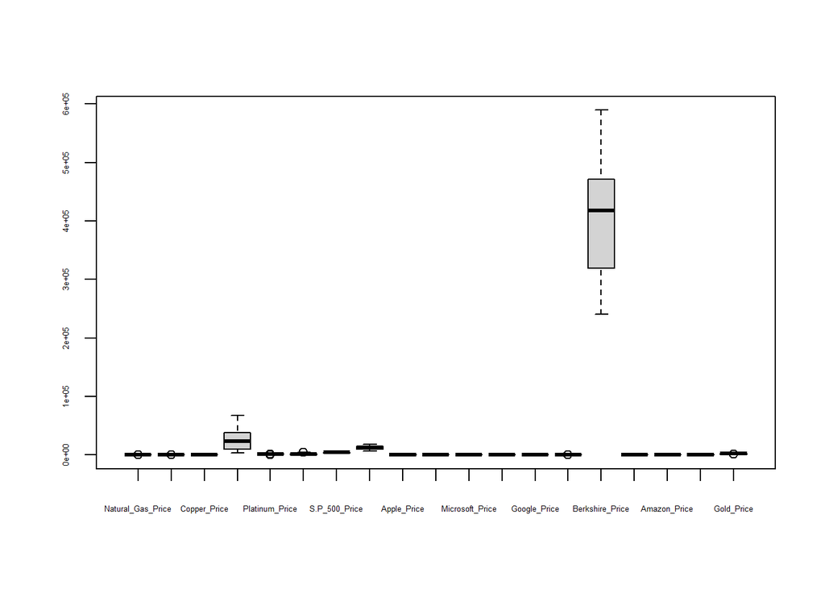

```r
boxplot(d, cex.axis=0.4)
```

```r
# Podemos apreciar como el precio de la acción de Berkshire tiene mucha variabilidad en comparación a las demás variables y tiene una escala completamente diferente, habrá que normalizar las variables o de manera equivalente, trabajar con la matriz de correlaciones, también observamos la existencia de algunos valores atípicos en algunas variables.
```

DISTANCIA DE MAHALANOBIS:

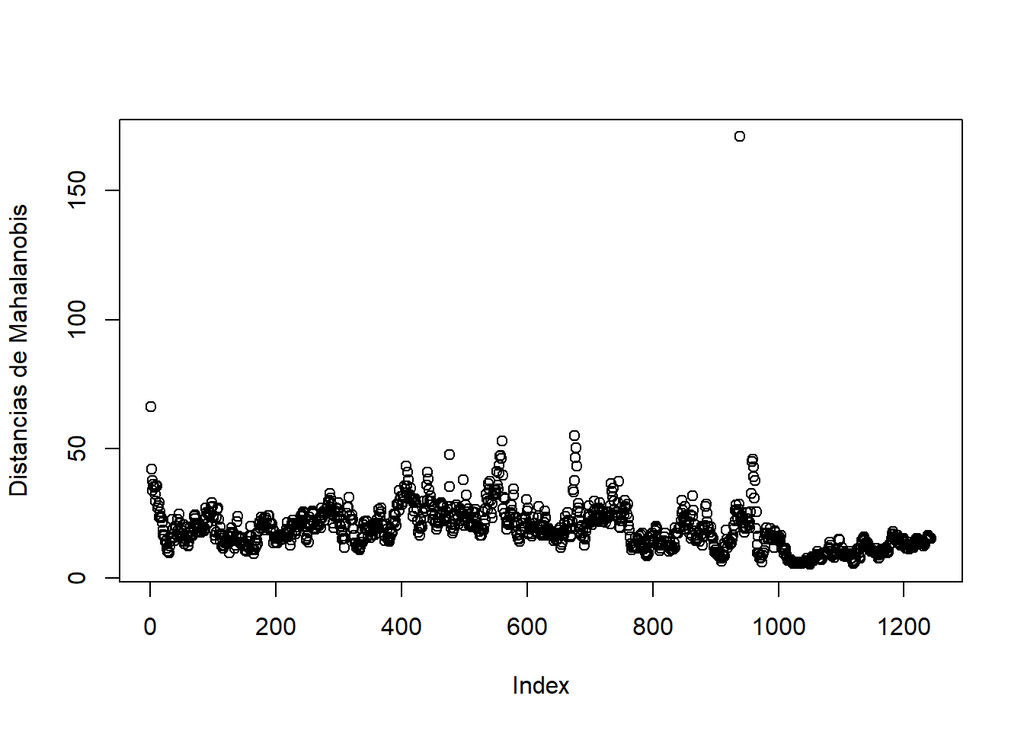

```r
# EL CÁLCULO DE LA DISTANCIA DE MAHALANOBIS PARA CADA FILA DE PRECIOS RESPECTO A LA MEDIA DE LA POBLACIÓN NOS PUEDE PROPORCIONAR INFORMACIÓN SOBRE LA EXISTENCIA DE DATOS ATÍPICOS, EN ESTE CASO, PODEMOS OBSERVAR UNA OBSERVACIÓN QUE SE ALEJA CONSIDERABLEMENTE DE LA MEDIA DE LA POBLACIÓN:

md <- mahalanobis(d, colMeans(d), cov(d))
plot(md, ylab = 'Distancias de Mahalanobis')
```

```r
# Podemos observar varios valores atípicos pero hay uno que su distancia es muy grande respecto a la media y varianza de la población, de momento no lo trataremos pero lo tendremos en cuenta por si nos causa efectos negativos a la hora de construir el modelo.
```

```r
# DURANTE LA CONSTRUCCIÓN DEL MODELO OBSERVAMOS QUE ESTE DATO TAN ATÍPICO PUEDE TOMAR MUCHO PESO A LA HORA DE CALCULAR LOS COEFICIENTES ÓPTIMOS Y HACER QUE LA RECTA DE REGRESIÓN VARÍE INCORRECTAMENTE SU AJUSTE RESPECTO A LA MAYORÍA DE LOS DEMÁS DATOS.

# POR TANTO, OPTAMOS A ELIMINAR ESTA OBSERVACIÓN:
which.max(md)
```

```
## [1] 939
```

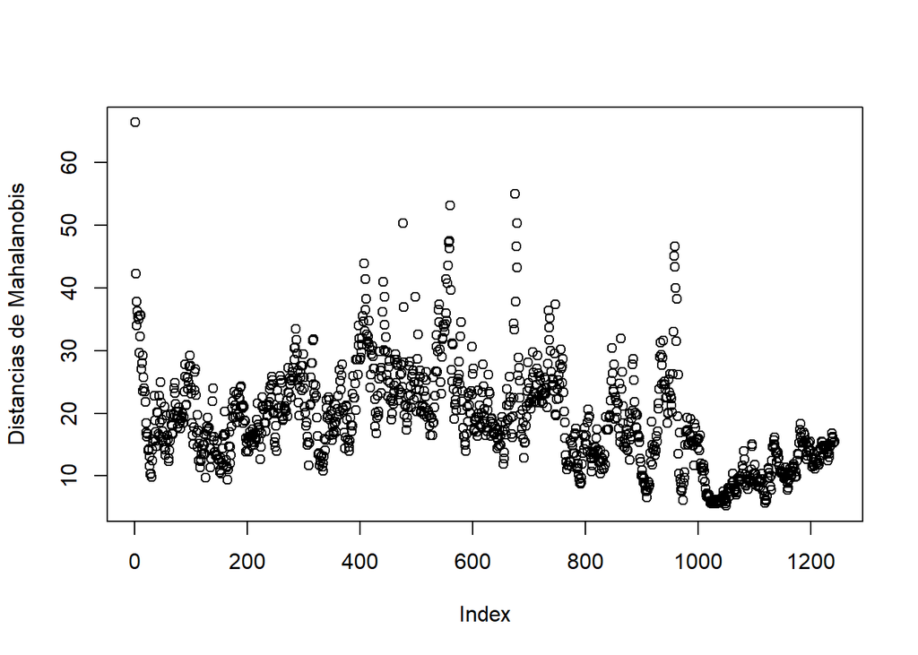

```r
d <- d[-939,]

md <- mahalanobis(d, colMeans(d), cov(d))
plot(md, ylab = 'Distancias de Mahalanobis')
```